# Introduction to SQLite3

## Nicholas Branco

The purpose of this is to introduce some SQLite concepts and ensure that I am able to go into a SQLite database (and, by extension, SQL) to extract and analyze data.

The SQL database that was provided can be found here:

https://www.kaggle.com/hugomathien/soccer/version/10

The database has data on soccer players and the attributes that may factor into winning a game. If you would like to read more, I suggest reading the Kaggle page.

For this assignment, I am pulling out five attributes and plotting them against each other to see if there is any correlation.

### Imports

```python
import numpy            as np
import pandas           as pd
import sqlite3
import matplotlib.pylab as plt

np.set_printoptions(precision=15)
```

### Getting data from the SQL database

The first thing to do is to connect to the database using a connection object. Generally, this is called "conn".

```python
conn = sqlite3.connect('database.sqlite')
```

We also need a cursor object in order to be able to access the data.

```python
c = conn.cursor()
```

We need the list of the tables in the database. To do that, we use the SELECT command to select all tables. SQL commands are usually written in all caps as a convention.

```python
c.execute("SELECT name FROM sqlite_master WHERE type='table';") # Give us all tables in the master table

print ('TABLES')
print ('******************************************')
print (c.fetchall()) # This command fetches all the data that we obtained using the execute command.
```

```
TABLES
[('sqlite_sequence',), ('Player_Attributes',), ('Player',), ('Match',), ('League',), ('Country',), ('Team',), ('Team_Attributes',)]
```

What a nice list of all the tables in the database! What can we find in the player attributes table?

```python
c.execute("PRAGMA table_info(Player_Attributes)") # Gets us table information

print ('Columns in Player_Attributes Table')
print ('******************************************')
print (c.fetchall()) # This command fetches all the data that we obtained using the execute command.
```

[output not shown]

The attributes I am choosing to analyze are:

1. Potential
2. Agility
3. Shot Power
4. Stamina
5. Aggression

If these end up not being numerical, I will have to change the attributes that I am looking at. Fortunately, I know these are numerical from looking into the database.

```python
c.execute("SELECT potential, agility, shot_power, stamina, aggression FROM Player_Attributes") # Give us the data we want.

allrows = c.fetchall()
```

The command we just did returns a list of tuples, so we will have to work around that. To do so, I will be making a list and putting all the rows one by one into the list, then convert that list into an array.

### Changing the data into a useful form

```python
soccerlist = [] # Empty list

for row in allrows:
    soccerlist.append(list(row)) # Put all the rows into the list

soccerarray = np.array(soccerlist, dtype=float)

print ('Our Array')
print ('***************************')
print (soccerarray)
```

```
Our Array
[[ 71.  59.  55.  54.  71.]
 [ 71.  59.  55.  54.  71.]
 [ 66.  59.  55.  54.  63.]
 ...,
 [ 80.  77.  75.  66.  67.]
 [ 81.  77.  72.  67.  63.]
 [ 81.  77.  72.  67.  63.]]
```

We need to make sure there are no N/A values in our array. To do that, we use the following numpy command.

```python
play_att = soccerarray[~np.isnan(soccerarray).any(axis=1)]
```

Now we can finally make the scatterplots!

### Plotting

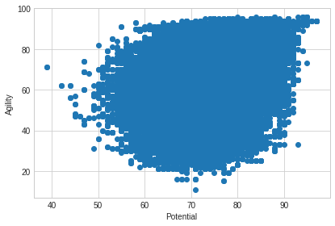

```python
with plt.style.context('seaborn-whitegrid'):
    plt.figure(figsize=(6, 4))
    plt.scatter(play_att[:,0], play_att[:,1])
    plt.xlabel('Potential')
    plt.ylabel('Agility')
    plt.legend(loc='lower center')
    plt.tight_layout()
    plt.show()
```

Okay, so doing ten of these graphs will be alot of copy and pasting and not the best way to look at everything. Luckily, there is a pandas command to put everything into one nice grid of graphs.

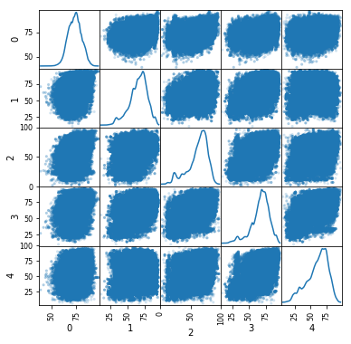

```python
df = pd.DataFrame(play_att)
pd.plotting.scatter_matrix(df, alpha=0.2, figsize=(6,6), diagonal='kde')
plt.show()
```

That looks much better, but I have no idea what 0, 1, 2, 3, and 4 all pertain to (well, I do but it's not clear from the graph which is which.)

That "diagonal='kde'" business basically means that the graph is plotting the density of the graph rather than the relation since the relation would just be a straight line and that's boring.

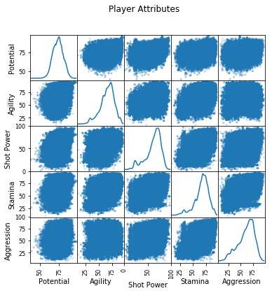

```python
df = pd.DataFrame(play_att, columns=['Potential','Agility','Shot Power','Stamina','Aggression'])
pd.plotting.scatter_matrix(df, alpha=0.2, figsize=(6,6), diagonal='kde')
plt.suptitle("Player Attributes")
plt.show()
```